# Predicting 2016 Election Results in the USA

The following R Markdown outlines the steps used by Ian Jeffries to predict the 2016 election results in the USA by county, based on the demographics of that county. This is a supervised machine learning classification problem, and three models were tested to predict the election outcome: K Nearest Neighbor, Artifical Neural Networks, and Decision Trees.

## Install necessary packages

The following code will install the packages used in the project:

```r
#list of packages used
packages <- c("dplyr", "tidyr", "ggplot2", "class", "rpart", "rpart.plot", "neuralnet", "arules",
              "plyr", "mltools", "arulesViz", "plotly", "RCurl")

#check to see if package is already installed, if not, install
for(p in packages){
  if(!require(p, character.only = TRUE)) {
    install.packages(p)
    library(p, character.only = TRUE)
  }
}
```

## Explore the Demographics Dataset

Import the data from my github page and explore.

```r
#import our county features dataset
path <- "https://raw.githubusercontent.com/ianjeffries/election-predictions/master/Data/county_facts.csv"
demographics <- read.csv(path, header=TRUE)

#See the names of the columns
names(demographics)
```

```
##  [1] "fips"               "area_name"          "state_abbreviation"
##  [4] "PST045214"          "PST040210"          "PST120214"
##  [7] "POP010210"          "AGE135214"          "AGE295214"
## [10] "AGE775214"          "SEX255214"          "RHI125214"
## [13] "RHI225214"          "RHI325214"          "RHI425214"
## [16] "RHI525214"          "RHI625214"          "RHI725214"
## [19] "RHI825214"          "POP715213"          "POP645213"
## [22] "POP815213"          "EDU635213"          "EDU685213"
## [25] "VET605213"          "LFE305213"          "HSG010214"
## [28] "HSG445213"          "HSG096213"          "HSG495213"
## [31] "HSD410213"          "HSD310213"          "INC910213"
## [34] "INC110213"          "PVY020213"          "BZA010213"
## [37] "BZA110213"          "BZA115213"          "NES010213"
## [40] "SBO001207"          "SBO315207"          "SBO115207"
## [43] "SBO215207"          "SBO515207"          "SBO415207"
## [46] "SBO015207"          "MAN450207"          "WTN220207"
## [49] "RTN130207"          "RTN131207"          "AFN120207"
## [52] "BPS030214"          "LND110210"          "POP060210"
```

```r
#See the structure of the dataset
str(demographics)
```

```
## 'data.frame':    3195 obs. of  54 variables:
##  $ fips              : int  0 1000 1001 1003 1005 1007 1009 1011 1013 1015 ...
##  $ area_name         : Factor w/ 1929 levels "Abbeville County",..: 1764 10 87 94 105 155 170 231 241 254 ...
##  $ state_abbreviation: Factor w/ 52 levels "","AK","AL","AR",..: 1 1 3 3 3 3 3 3 3 3 ...
##  $ PST045214         : int  318857056 4849377 55395 200111 26887 22506 57719 10764 20296 115916 ...
##  $ PST040210         : int  308758105 4780127 54571 182265 27457 22919 57322 10915 20946 118586 ...
##  $ PST120214         : num  3.3 1.4 1.5 9.8 -2.1 -1.8 0.7 -1.4 -3.1 -2.3 ...
##  $ POP010210         : int  308745538 4779736 54571 182265 27457 22915 57322 10914 20947 118572 ...
##  $ AGE135214         : num  6.2 6.1 6 5.6 5.7 5.3 6.1 6.3 6.1 5.7 ...
##  $ AGE295214         : num  23.1 22.8 25.2 22.2 21.2 21 23.6 21.4 23.6 22.2 ...
##  $ AGE775214         : num  14.5 15.3 13.8 18.7 16.5 14.8 17 14.9 18 16 ...
##  $ SEX255214         : num  50.8 51.5 51.4 51.2 46.6 45.9 50.5 45.3 53.6 51.8 ...
##  $ RHI125214         : num  77.4 69.7 77.9 87.1 50.2 76.3 96 26.9 53.9 75.8 ...
##  $ RHI225214         : num  13.2 26.7 18.7 9.6 47.6 22.1 1.8 70.1 44 21.1 ...
##  $ RHI325214         : num  1.2 0.7 0.5 0.7 0.6 0.4 0.6 0.8 0.4 0.5 ...
```

[output cut: 40 more lines]

```r
#find the state summary info and remove (want only counties, this dataset includes state summaries)
demographics <- demographics[-which(demographics$state_abbreviation == ""), ]
```

## Add in Dictionary information

Add in the dictionary file to replace columm headers with readable values.

```r
#pull in dictionary to get true names of the variables
path <- "https://raw.githubusercontent.com/ianjeffries/election-predictions/master/Data/county_facts_dictionary.csv"
var_names <- read.csv(path, header = TRUE)

#view variable names
print(var_names)
```

```
##           column_name
## 1           PST045214
## 2           PST040210
## 3           PST120214
## 4           POP010210
## 5           AGE135214
## 6           AGE295214
## 7           AGE775214
## 8           SEX255214
## 9           RHI125214
## 10          RHI225214
## 11          RHI325214
## 12          RHI425214
## 13          RHI525214
## 14          RHI625214
```

[output cut: 99 more lines]

## Pull in 2016 Election Results and Clean the Data

As of now, the US primarily operates in a two-party system. Because of this, only the democratic and republican candidates are of interest.

```r
#add in the election results
path <- "https://raw.githubusercontent.com/ianjeffries/election-predictions/master/Data/pres16results.csv"
election_results <- read.csv(path, header = TRUE)

#see the names of the columns
names(election_results)
```

```
## [1] "county"      "fips"        "cand"        "st"          "pct_report"
## [6] "votes"       "total_votes" "pct"         "lead"
```

```r
#see structure of the dataset
str(election_results)
```

```
## 'data.frame':    18475 obs. of  9 variables:
##  $ county     : Factor w/ 1969 levels "Abbeville County",..: NA NA NA NA NA NA NA NA NA NA ...
##  $ fips       : Factor w/ 3289 levels "10001","10003",..: 3282 3282 3282 3282 3282 3282 3282 3282 3282 3282 ...
##  $ cand       : Factor w/ 32 levels " None of these candidates",..: 7 13 11 15 9 6 12 27 1 26 ...
##  $ st         : Factor w/ 52 levels "AK","AL","AR",..: 45 45 45 45 45 45 45 45 45 45 ...
##  $ pct_report : num  0.995 0.995 0.995 0.995 0.995 ...
##  $ votes      : int  60350241 60981118 4164589 1255968 451636 180877 48308 32120 28824 23501 ...
##  $ total_votes: int  127592176 127592176 127592176 127592176 127592176 127592176 127592176 127592176 127592176 127592176 ...
##  $ pct        : num  0.47299 0.47794 0.03264 0.00984 0.00354 ...
##  $ lead       : Factor w/ 2 levels "Donald Trump",..: 1 1 1 1 1 1 1 1 1 1 ...
```

```r
#drop columns we don't need
election_results <- election_results[-c(2, 5, 8)]

#filter by the republican and democratic candidates & remove null values
ER_clean <- election_results %>%
                      filter(cand %in% c("Donald Trump", "Hillary Clinton") & county != "<NA>")

#change to wide dataset to merge the election results with the demographics dataframe
ER_clean <- spread(ER_clean, key = cand, value = votes)

#add in % won by
ER_clean$Percent_Rep <- round(ER_clean$`Donald Trump` / ER_clean$total_votes, 2)
ER_clean$Percent_Dem <- round(ER_clean$`Hillary Clinton` / ER_clean$total_votes, 2)
```

## Join the Demographic and Election Results Datasets

Now that cleanup is complete, the two datasets can be joined.

```r
#join our election results with the demographics table
final_dataset <- left_join(demographics, select(ER_clean, Percent_Dem, Percent_Rep, st, county),
                           by = c("area_name" = "county", "state_abbreviation" = "st"))

#find number of counties with N/A election results
print(paste0("Number of counties with null election results: ",
             nrow(final_dataset[which(complete.cases(final_dataset) == FALSE), ])))
```

```
## [1] "Number of counties with null election results: 33"
```

```r
#looks like these aren't counties (the majority) and the N is small enough I feel comfortable removing them
final_dataset <- na.omit(final_dataset)
```

## Final Cleanup

The final cleanup steps are to remove irrelevant values and reassign column names for analysis. The data will also be normalized, with 0 or 1 values assigned to the target variable.

```r
#change any column in dataset based on % of the population to true percentage
#(basically already normalized between 0 and 1)
final_dataset[,c(8:24, 28:29, 35, 41:46)] <- final_dataset[,c(8:24, 28:29, 35, 41:46)] / 100

#drop clearly irrelevant values
final_dataset <- final_dataset[ , -c(5:8, 38)]

#assign headers to something more understandable, based on the dictionary dataframe
names(final_dataset) <- var_names$description[match(names(final_dataset), var_names$column_name)]

#assign labels that weren't in the dictionary
names(final_dataset[ , c(1, 2, 3, 50, 51)]) <- c("fips", "area_name", "state_abbreviation", "Percent_Dem",
                                                 "Percent_Rep")

#normalize any data not described as a %
for (i in c(4, 21, 22, 23, 26, 27, 28, 29, 30, 32, 33, 34, 35, 42, 43, 44, 45, 46, 47, 48, 49)) {
  final_dataset[,i] <- ((final_dataset[,i] - min(final_dataset[,i])) /
                          (max(final_dataset[,i]) - min(final_dataset[,i])) *
                          (1 - 0) + 0)
}

#add in 1 or 0 if they voted democratic or republican
final_dataset$Winner <- 0

for (i in 1:nrow(final_dataset)) {
    if (final_dataset[i, "percent_dem"] < .50) {
      final_dataset[i, "Winner"] <- 0
      } else {
        final_dataset[i, "Winner"] <- 1
      }}

#set winner column to factor for classification
final_dataset$Winner <- as.factor(final_dataset$Winner)
```

## Look for Variables to use in Classification

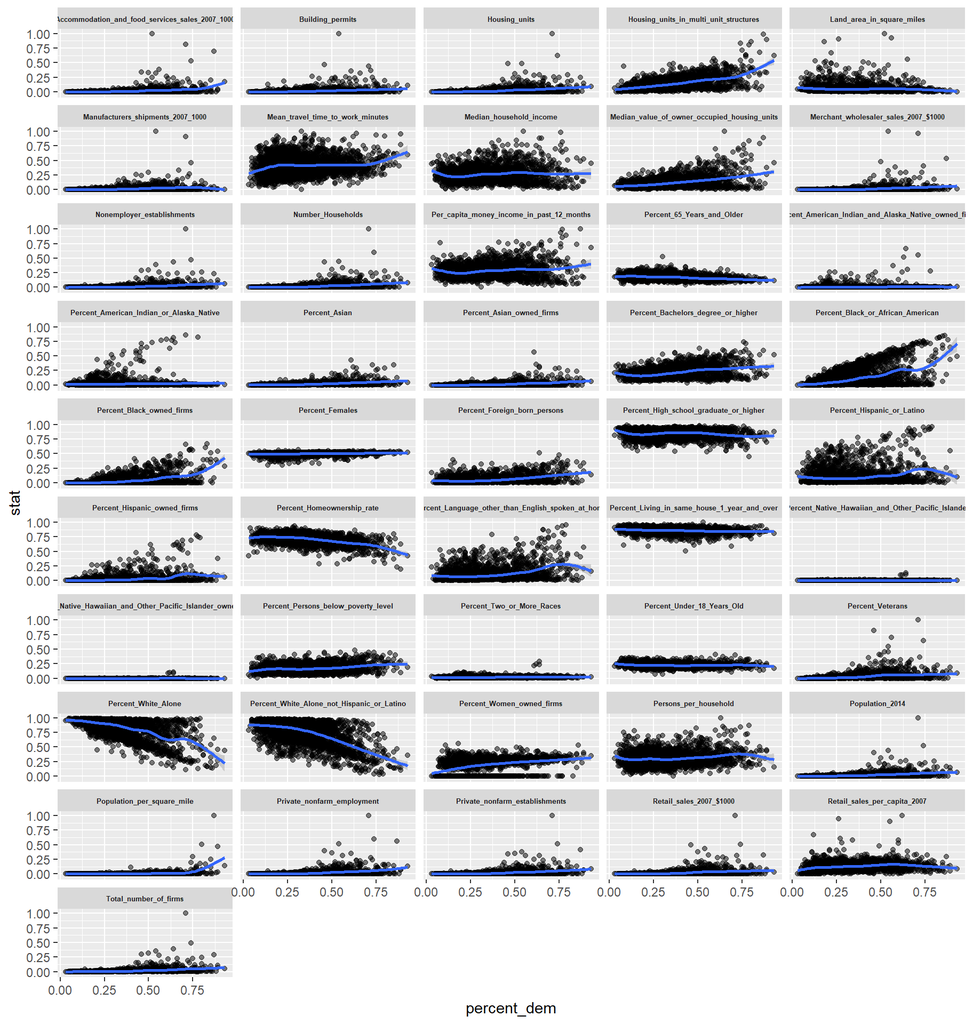

```r
#create narrow dataset to understand relationship between attributes and voting preference
final_narrow <- gather(final_dataset, key = demographic_measure, value = stat, 4:49)

#create side by side scatterplots to look for possible correlations
ggplot(final_narrow, aes(x = percent_dem, y = stat)) +
  geom_point(alpha = .5) +
  geom_smooth() +
  facet_wrap(vars(demographic_measure), ncol = 5) +
  theme(strip.text = element_text(size = 5, face = "bold"))
```

```r
#remove columns that don't seem to have a correlation to voting preference
final_dataset <- final_dataset[ , -c(1,5,7,10,12,13,16,28,30,34,35,37,39,42,43,44,45,47,48)]
```

## Classification Prep Work

Before the models can be created, training and test datasets must be set up. An accuracy matrix was also created to house the results from each model.

```r
###### CREATE TRAINING AND TEST DATASETS ######

#take only the predictor values and class from our dataset
e_predictions <- final_dataset[ , c(3:30, 33)]

#set set to make our test data reproducable
set.seed(111692)

#get 80/20 sample of data
dist <- sample(2, size = nrow(e_predictions), replace = TRUE, prob = c(.8, .2))

#set test and training data
e_training <- e_predictions[dist == 1, ]
e_test <- e_predictions[dist == 2, ]

#show dimensions of training dataset
dim(e_training)
```

```
## [1] 2434   29
```

```r
#show dimensions of test dataset
dim(e_test)
```

```
## [1] 676  29
```

```r
#create accuracy table for comparison
algorithm_results <- matrix(data = rep(0, 6), nrow = 2, ncol = 3,
                            dimnames = list(c("Accuracy %:", "Precision %:"), c("KNN", "DTREE", "ANN")))

#show accuracy table
print(algorithm_results)
```

```
##              KNN DTREE ANN
## Accuracy %:    0     0   0
## Precision %:   0     0   0
```

## K-Nearest Neighbor Classification

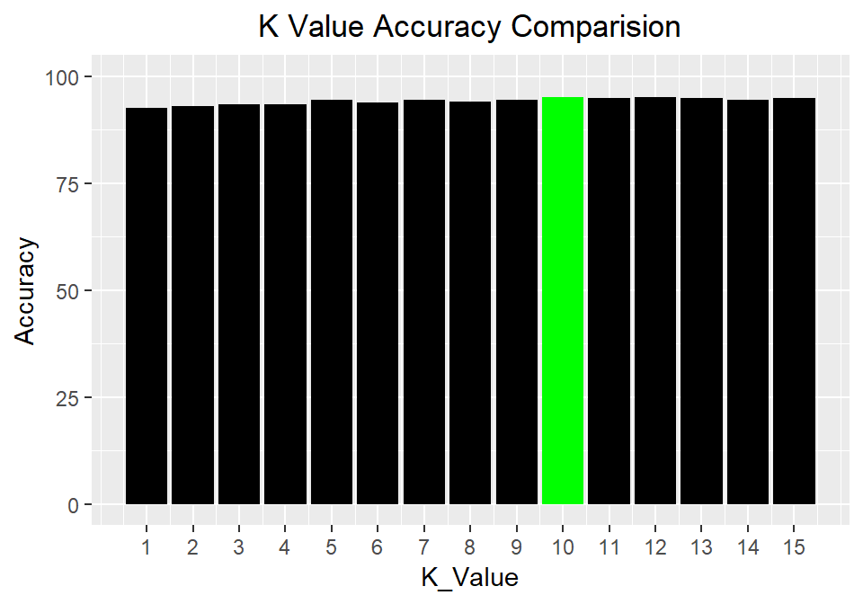

```r
###### KNN CLASSIFICATION ######

#create KNN accuracy matrix to compare 15 K-Values
KNN_accuracy <- matrix(data= rep(0, 45), ncol = 3, dimnames = list(c(1:15), c("K_Value", "Accuracy",
                                                                              "Precision")))

#set each K value as a factor
KNN_accuracy[ , 1] <- as.factor(c(1:15))

#test multiple K values and store the results
#(For KNN function, you need to remove the columns with actual classification)
for (i in 1:15) {
  KNN_results <- as.data.frame(knn(e_training[,1:28], e_test[,1:28], e_training$Winner,
                                 k = i, prob = TRUE))

  #create a comparison table
  KNN_table <- table(KNN_results[,1], e_test$Winner)

  #find % accuracy
  KNN_accuracy[i , 2] <- round(((sum(diag(KNN_table)) / sum(KNN_table)) * 100), 2)

  #find % precision
  KNN_accuracy[i , 3] <- round((KNN_table[2, 2] / (KNN_table[2, 2] + KNN_table[2, 1]) * 100), 2)
}

#plot accuracy results
theme_update(plot.title = element_text(hjust = 0.5))
ggplot(as.data.frame(KNN_accuracy), aes(x = K_Value, y = Accuracy)) +
  geom_bar(stat = "identity", fill = "black") +
  ggtitle("K Value Accuracy Comparision") +
  scale_x_continuous(breaks = c(1:15)) +
  scale_y_continuous(limits = c(0, 100)) +
  geom_bar(data=subset(as.data.frame(KNN_accuracy), Accuracy==max(Accuracy)), aes(K_Value, Accuracy),
           fill="green", stat="identity")
```

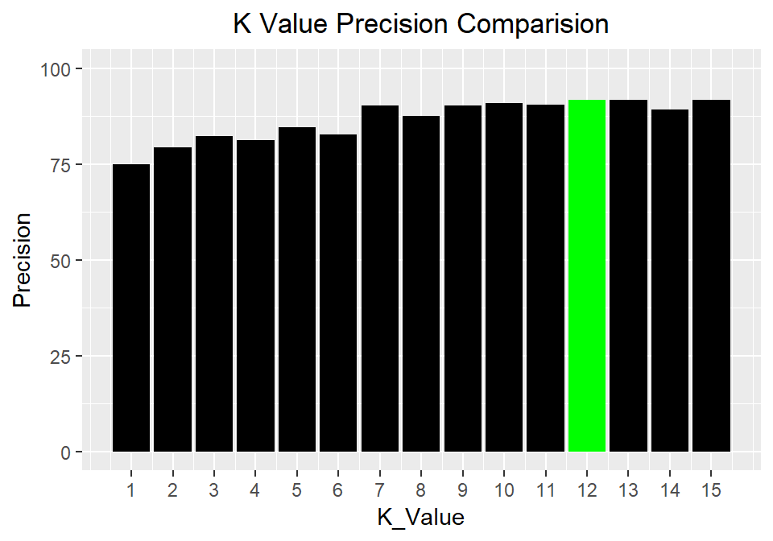

```r
#plot precision results
ggplot(as.data.frame(KNN_accuracy), aes(x = K_Value, y = Precision)) +
  geom_bar(stat = "identity", fill = "black") +
  ggtitle("K Value Precision Comparision") +
  scale_x_continuous(breaks = c(1:15)) +
  scale_y_continuous(limits = c(0, 100)) +
  geom_bar(data=subset(as.data.frame(KNN_accuracy), Precision==max(Precision)), aes(K_Value, Precision),
           fill="green", stat="identity")
```

```r
#add to results table (highest k value at the time I ran)
algorithm_results[1:2, 1] <- KNN_accuracy[12, 2:3]
```

## Decision Tree

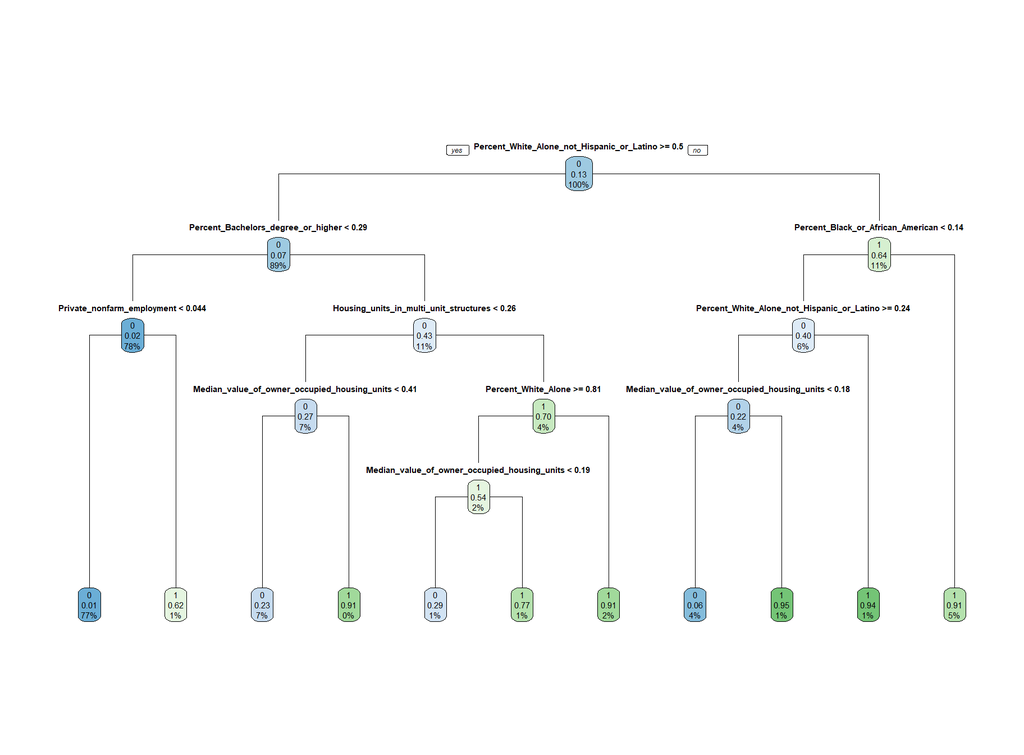

```r
###### DECISION TREE CLASSIFICATION ######

#Train the decision tree
e_tree <- rpart(Winner ~ ., data = e_training)

#plot the branches of the tree
rpart.plot(e_tree, type=1)
```

```r
#returns a list of strings summarizing the branch path to each node
rpart.rules(e_tree, style = "tall") #useful to see what conditions predict a certain factor
```

```
## Winner is 0.01 when
##     Percent_White_Alone_not_Hispanic_or_Latino >= 0.50
##     Percent_Bachelors_degree_or_higher < 0.29
##     Private_nonfarm_employment < 0.044
##
## Winner is 0.06 when
##     Percent_White_Alone_not_Hispanic_or_Latino is 0.24 to 0.50
##     Median_value_of_owner_occupied_housing_units < 0.18
##     Percent_Black_or_African_American < 0.14
##
## Winner is 0.23 when
##     Percent_White_Alone_not_Hispanic_or_Latino >= 0.50
##     Percent_Bachelors_degree_or_higher >= 0.29
##     Median_value_of_owner_occupied_housing_units < 0.41
##     Housing_units_in_multi_unit_structures < 0.26
##
## Winner is 0.29 when
##     Percent_White_Alone_not_Hispanic_or_Latino >= 0.50
##     Percent_Bachelors_degree_or_higher >= 0.29
##     Median_value_of_owner_occupied_housing_units < 0.19
##     Housing_units_in_multi_unit_structures >= 0.26
##     Percent_White_Alone >= 0.81
##
## Winner is 0.62 when
##     Percent_White_Alone_not_Hispanic_or_Latino >= 0.50
##     Percent_Bachelors_degree_or_higher < 0.29
##     Private_nonfarm_employment >= 0.044
##
## Winner is 0.77 when
##     Percent_White_Alone_not_Hispanic_or_Latino >= 0.50
##     Percent_Bachelors_degree_or_higher >= 0.29
##     Median_value_of_owner_occupied_housing_units >= 0.19
##     Housing_units_in_multi_unit_structures >= 0.26
##     Percent_White_Alone >= 0.81
##
## Winner is 0.91 when
##     Percent_White_Alone_not_Hispanic_or_Latino < 0.50
##     Percent_Black_or_African_American >= 0.14
##
## Winner is 0.91 when
##     Percent_White_Alone_not_Hispanic_or_Latino >= 0.50
##     Percent_Bachelors_degree_or_higher >= 0.29
##     Median_value_of_owner_occupied_housing_units >= 0.41
##     Housing_units_in_multi_unit_structures < 0.26
##
## Winner is 0.91 when
##     Percent_White_Alone_not_Hispanic_or_Latino >= 0.50
##     Percent_Bachelors_degree_or_higher >= 0.29
##     Housing_units_in_multi_unit_structures >= 0.26
##     Percent_White_Alone < 0.81
##
## Winner is 0.94 when
##     Percent_White_Alone_not_Hispanic_or_Latino < 0.24
##     Percent_Black_or_African_American < 0.14
##
## Winner is 0.95 when
##     Percent_White_Alone_not_Hispanic_or_Latino is 0.24 to 0.50
##     Median_value_of_owner_occupied_housing_units >= 0.18
##     Percent_Black_or_African_American < 0.14
```

```r
#predict using that model on test data
tree_results <- as.data.frame(predict(e_tree, newdata = e_test, type = "class"))

#create a comparison table
tree_table <- table(tree_results[ , 1], e_test$Winner)

#create an accuracy table
tree_accuracy <- matrix(data= rep(0, 2), ncol = 2, dimnames = list("%",c("Accuracy", "Precision")))

#find accuracy
tree_accuracy[1, 1] <- round(((sum(diag(tree_table)) / sum(tree_table)) * 100), 2)

#find % precision
tree_accuracy[1 , 2] <- round((tree_table[2, 2] / (tree_table[2, 2] + tree_table[2, 1]) * 100), 2)

#add to results table
algorithm_results[1:2, 2] <- tree_accuracy
```

## Neural Networks

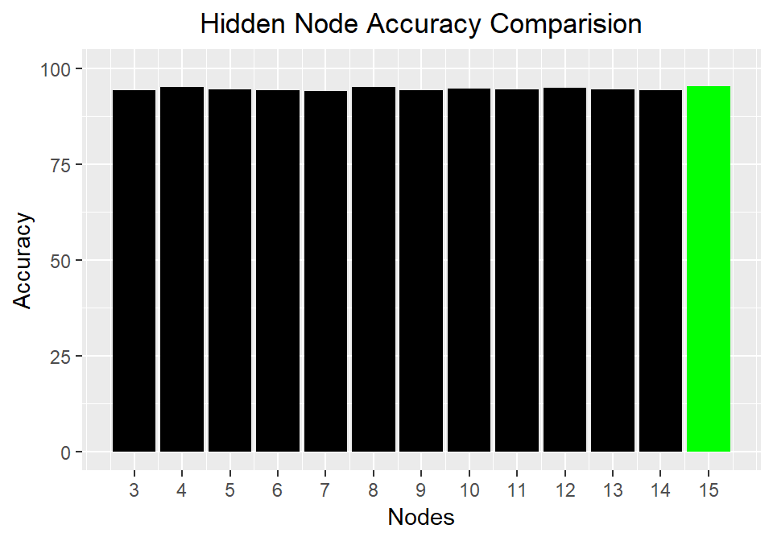

```r
###### ANN CLASSIFICATION ######

#build the neural network

#neural networks do not work for categorical variables (ie 1, 2 or 3 ranking) To get around this we put each
#variable in it's own column, either a 1 or 0 for columns 1, 2 or 3 (use the model.matrix function to do this)

#first move categorical variables into their own columns
#(I believe this formula finds columns that are categorical classes)
e_training_m <- model.matrix(~0 + ., data = e_training)

#do the same for the test dataset
e_test_m <- model.matrix(~0 + ., data = e_test)

#create an accuracy table
ANN_accuracy <- matrix(data= rep(0, 39), ncol = 3, dimnames = list(c(3:15), c("Nodes", "Accuracy",
                                                                              "Precision")))

ANN_accuracy[ , 1] <- c(3:15)

#test multiple hidden nodes in our model
for (i in 3:15) {

  #build the artifical neural network using neuralnet function
  e_network <- neuralnet(Winner0 + Winner1 ~ Population_2014 + Percent_65_Years_and_Older +
                           Percent_White_Alone + Percent_Black_or_African_American + Percent_Asian +
                           Percent_Hispanic_or_Latino + Percent_White_Alone_not_Hispanic_or_Latino +
                           Percent_Foreign_born_persons + Percent_Language_other_than_English_spoken_at_home +
                           Percent_High_school_graduate_or_higher + Percent_Bachelors_degree_or_higher +
                           Percent_Veterans + Mean_travel_time_to_work_minutes + Housing_units +
                           Percent_Homeownership_rate + Housing_units_in_multi_unit_structures +
                           Median_value_of_owner_occupied_housing_units + Number_Households +
                           Per_capita_money_income_in_past_12_months + Percent_Persons_below_poverty_level +
                           Private_nonfarm_establishments + Private_nonfarm_employment +
                           Percent_Black_owned_firms + Percent_Asian_owned_firms +
                           Percent_Hispanic_owned_firms + Percent_Women_owned_firms +
                           Accommodation_and_food_services_sales_2007_1000 + Population_per_square_mile,
                         data = e_training_m,
                         hidden = i,
                         lifesign = "full",
                         linear.output = FALSE,
                         threshold = .1)

  #test the ANN on the test data
  ANN_results <- compute(e_network, e_test_m[ ,1:28]) #computes result of each row, remove winner variables

  #extract the results
  prediction <- ANN_results$net.result

  #use max.col function to pull the original values from our test dataset into one column
  original_values <- max.col(e_test_m[ ,29:30]) - 1

  #use max.col function to get prediction values
  prediction_values <- max.col(prediction) - 1

  #create a dataframe with both values
  results <- data.frame(actual = original_values, prediction = prediction_values)

  #create a comparison table
  ANN_table <- table(results$prediction, e_test$Winner)

  #find accuracy
  ANN_accuracy[i-2, 2] <- round(((sum(diag(ANN_table)) / sum(ANN_table)) * 100), 2)

  #find % precision
  ANN_accuracy[i-2 , 3] <- round((ANN_table[2, 2] / (ANN_table[2, 2] + ANN_table[2, 1]) * 100), 2)
}

#plot the accuracy results
ggplot(as.data.frame(ANN_accuracy), aes(x = Nodes, y = Accuracy)) +
  geom_bar(stat = "identity", fill = "black") +
  ggtitle("Hidden Node Accuracy Comparision") +
  scale_x_continuous(breaks = c(3:15)) +
  scale_y_continuous(limits = c(0, 100)) +
  geom_bar(data=subset(as.data.frame(ANN_accuracy), Accuracy==max(Accuracy)), aes(Nodes, Accuracy),
           fill="green", stat="identity")
```

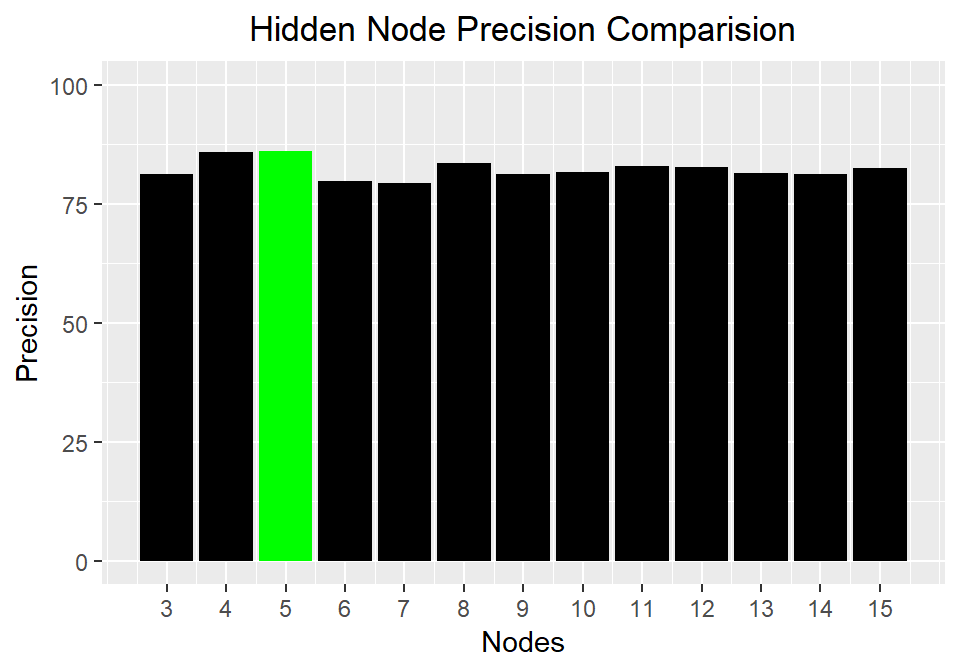

```r
#plot the precision results
ggplot(as.data.frame(ANN_accuracy), aes(x = Nodes, y = Precision)) +
  geom_bar(stat = "identity", fill = "black") +
  ggtitle("Hidden Node Precision Comparision") +
  scale_x_continuous(breaks = c(3:15)) +
  scale_y_continuous(limits = c(0, 100)) +
  geom_bar(data=subset(as.data.frame(ANN_accuracy), Precision==max(Precision)), aes(Nodes, Precision),
           fill="green", stat="identity")
```

```r
#add to results table
algorithm_results[1:2, 3] <- ANN_accuracy[1, 2:3]
print(algorithm_results)
```

```
##                KNN DTREE   ANN
## Accuracy %:  94.97 93.79 94.23
## Precision %: 91.78 79.12 81.11
```

## Model Comparison

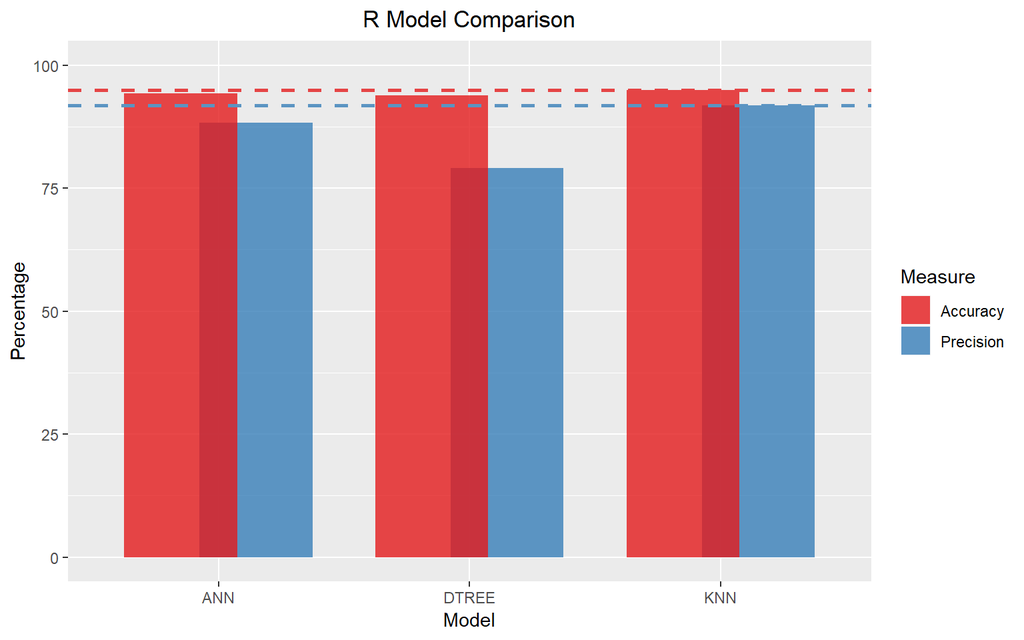

```r
###### COMPARISON OF CLASSIFICATION MODELS ######

#create final results (results kept changing as I used different work stations,
#                       using values from last test for the write up)
final_results <- matrix(data= rep(0, 18), ncol = 3, dimnames = list(c(1:6), c("Model", "Measure",
                                                                              "Percentage")))
final_results <- as.data.frame(final_results)

#add results manually
final_results$Model <- c("KNN", "DTREE", "ANN", "KNN", "DTREE", "ANN")
final_results$Measure <- c("Accuracy", "Accuracy", "Accuracy", "Precision", "Precision", "Precision")
final_results$Percentage <- c(94.97, 93.79, 94.23, 91.78, 79.12, 88.31)

#plot the accuracy results
ggplot(final_results, aes(x = Model, y = Percentage, fill = Measure)) +
  geom_bar(stat = "identity", position = position_dodge(width = .6), alpha = .8) +
  ggtitle("R Model Comparison") +
  scale_y_continuous(limits = c(0, 100)) +
  geom_hline(yintercept = 94.97, linetype = "dashed", size = 1, color = "#E54445") +
  geom_hline(yintercept = 91.78, linetype = "dashed", size = 1, color = "#5B94C2") +
  scale_fill_brewer(palette = "Set1")
```

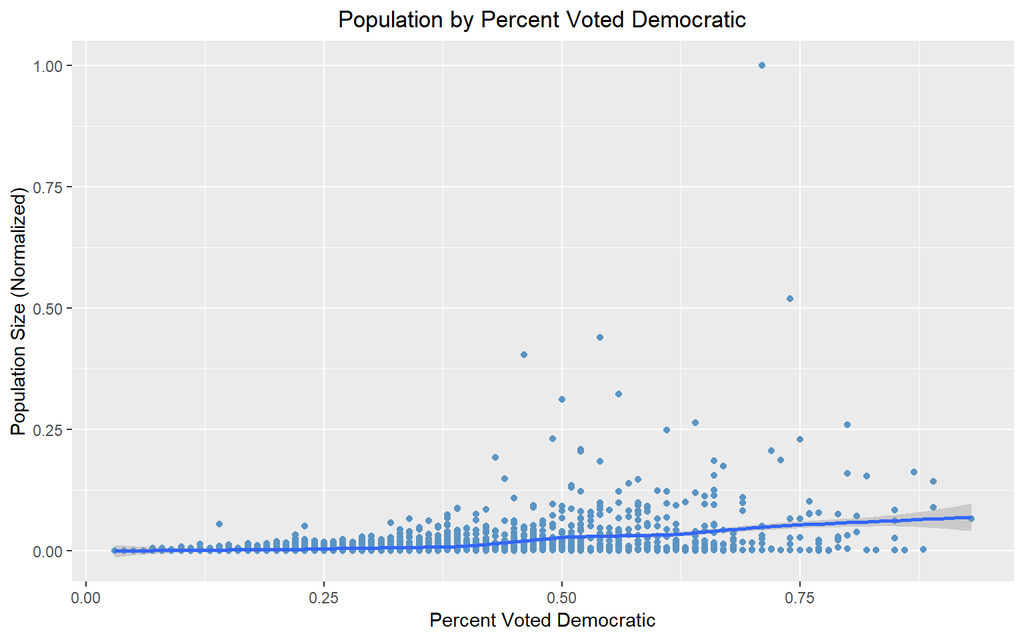

```r
#make narrow dataset even more narrow to plot by party
final_narrow2 <- gather(final_narrow, key = party, value = percent, 4:5)

#plot vote by population (to see if high populations voted democratic)
final_narrow2 %>%
  filter(demographic_measure == "Population_2014",
         party == "percent_dem") %>%
  ggplot(aes(x = percent, y = stat)) +
  geom_point(color = "#5B94C2") +
  geom_smooth() +
  xlab("Percent Voted Democratic") +
  ylab("Population Size (Normalized)") +
  ggtitle("Population by Percent Voted Democratic")
```

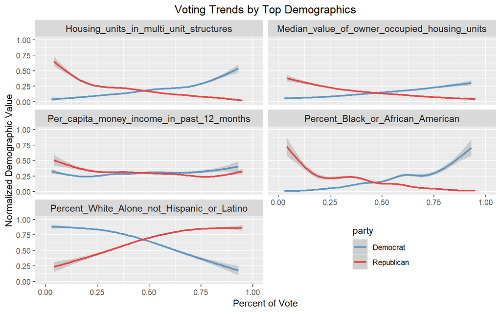

```r
#plot top demographics
final_narrow2 %>%
  filter(demographic_measure == "Percent_White_Alone_not_Hispanic_or_Latino" |
         demographic_measure == "Percent_Black_or_African_American" |
         demographic_measure == "Housing_units_in_multi_unit_structures" |
         demographic_measure == "Per_capita_money_income_in_past_12_months" |
         demographic_measure == "Median_value_of_owner_occupied_housing_units") %>%
  ggplot(aes(x = percent, y = stat, color = party)) +
  geom_smooth() +
  facet_wrap(~demographic_measure, ncol = 2) +
  ggtitle("Voting Trends by Top Demographics") +
  xlab("Percent of Vote") +
  ylab("Normalized Demographic Value") +
  theme(strip.text = element_text(size=11), legend.position = c(0.75, 0.15)) +
  scale_colour_manual(labels = c("Democrat", "Republican"), values = c("#5B94C2", "#E54445")) +
  scale_x_continuous(limits = c(0, 1), breaks = c(0, 0.25, 0.5, 0.75, 1)) +
  scale_y_continuous(limits = c(0, 1), breaks = c(0, 0.25, 0.5, 0.75, 1))
```

## Conclusion

In conclusion, KNN was the best performing model to use when predicting election results by county. A full write-up of the results can be found on Ian Jeffries’ github page.